# DM_Assignment4_Duo_Zhou_Part2

Duo Zhou

8/8/2020

```r
dataPath <- "C:/Users/zd000/Desktop/MSCA/Data Mining/Assignments/week4/"
DB.train <-read.csv(paste(dataPath, 'DBtrain.csv', sep = '/'), header = TRUE)
DB.test <-read.csv(paste(dataPath, 'DBtest.csv', sep = '/'), header = TRUE)
head(DB.train)
```

```
##              race gender age admission_type_id discharge_disposition_id
## 1 AfricanAmerican      0  75                 3                        1
## 2       Caucasian      1  65                 1                        3
## 3       Caucasian      0  55                 1                        3
## 4       Caucasian      0  45                 3                        1
## 5 AfricanAmerican      0  45                 5                       25
## 6 AfricanAmerican      0  85                 1                        3
##   time_in_hospital num_lab_procedures num_procedures num_medications
## 1                2                  1              1               8
## 2                3                  1              0              25
## 3                1                 49              0              13
## 4                4                 40              5              15
## 5               11                 78              1              19
## 6                3                 38              1              15
##   number_outpatient number_emergency number_inpatient      diag_1
```

[output cut: 41 more lines]

```r
head(DB.test)
```

```
##              race gender age admission_type_id discharge_disposition_id
## 1       Caucasian      1  45                 1                        1
## 2       Caucasian      0  85                 1                        1
## 3       Caucasian      0  95                 3                        3
## 4       Caucasian      0  45                 1                        3
## 5       Caucasian      1  85                 1                        6
## 6 AfricanAmerican      0  65                 3                        1
##   time_in_hospital num_lab_procedures num_procedures num_medications
## 1                1                 51              0               8
## 2               13                 68              2              28
## 3               12                 33              3              18
## 4                7                 60              0              15
## 5               10                 55              1              31
## 6                1                 49              5               2
##   number_outpatient number_emergency number_inpatient      diag_1
```

[output cut: 41 more lines]

```r
dim(DB.train)
```

```
## [1] 48041    37
```

```r
dim(DB.test)
```

```
## [1] 20589    37
```

### Select categorical columns to covert to factors

```r
categorical_cols = c('race','admission_type_id','discharge_disposition_id','diag_1', 'max_glu_serum', 'A1Cresult', 'metformin',
     'repaglinide', 'nateglinide', 'chlorpropamide', 'glimepiride', 'glipizide', 'glyburide', 'tolbutamide',
     'pioglitazone', 'rosiglitazone', 'acarbose', 'miglitol', 'troglitazone', 'tolazamide', 'insulin', 'glyburide.metformin',
     'glipizide.metformin', 'metformin.pioglitazone','change','diabetesMed','readmitted','gender')

DB.train[,categorical_cols]<-lapply(DB.train[ ,categorical_cols],as.factor)
DB.test[,categorical_cols]<-lapply(DB.test[ ,categorical_cols],as.factor)
head(DB.train[,categorical_cols])
```

```
##              race admission_type_id discharge_disposition_id      diag_1
## 1 AfricanAmerican                 3                        1   Digestive
## 2       Caucasian                 1                        3       Other
## 3       Caucasian                 1                        3 Circulatory
## 4       Caucasian                 3                        1   Neoplasms
## 5 AfricanAmerican                 5                       25       Other
## 6 AfricanAmerican                 1                        3      Injury
##   max_glu_serum  A1Cresult metformin repaglinide nateglinide chlorpropamide
## 1    Not tested Not tested        No          No          No             No
## 2    Not tested Not tested        No          No          No             No
## 3    Not tested Not tested        No          No          No             No
## 4    Not tested Not tested        No          No          No             No
## 5    Not tested Not tested        No          No          No             No
## 6    Not tested Not tested        No          No          No             No
##   glimepiride glipizide glyburide tolbutamide pioglitazone rosiglitazone
```

[output cut: 27 more lines]

```r
head(DB.test[,categorical_cols])
```

```
##              race admission_type_id discharge_disposition_id      diag_1
## 1       Caucasian                 1                        1   Neoplasms
## 2       Caucasian                 1                        1 Circulatory
## 3       Caucasian                 3                        3 Circulatory
## 4       Caucasian                 1                        3 Circulatory
## 5       Caucasian                 1                        6 Circulatory
## 6 AfricanAmerican                 3                        1 Respiratory
##   max_glu_serum  A1Cresult metformin repaglinide nateglinide chlorpropamide
## 1    Not tested Not tested        No          No          No             No
## 2    Not tested Not tested        No          No          No             No
## 3    Not tested Not tested        No          No          No             No
## 4    Not tested Not tested    Steady          Up          No             No
## 5    Not tested Not tested        No          No          No             No
## 6    Not tested Not tested        No          No          No             No
##   glimepiride glipizide glyburide tolbutamide pioglitazone rosiglitazone
```

[output cut: 27 more lines]

Build a classification tree model using all the variables in the set.

```r
DB.tree.model <- rpart(DB.train$readmitted~.,data=DB.train,control=rpart.control(cp=0,minsplit=30,xval=10, maxsurrogate=0))
```

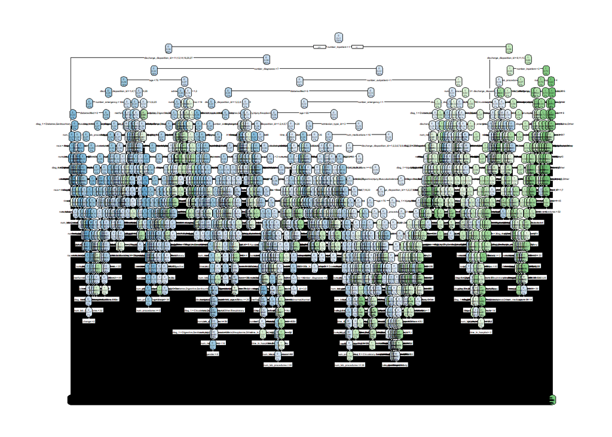

```r
rpart.plot(DB.tree.model)
```

This tree model is very hard to interpret. We can fix the interpetability problem by pruning the tree. The first step is to find the correct complexity parameter (cp). This is a value that penalizes overall fit by adding each node.

The optimal cp value can be found by choosing that minimizes xerror.

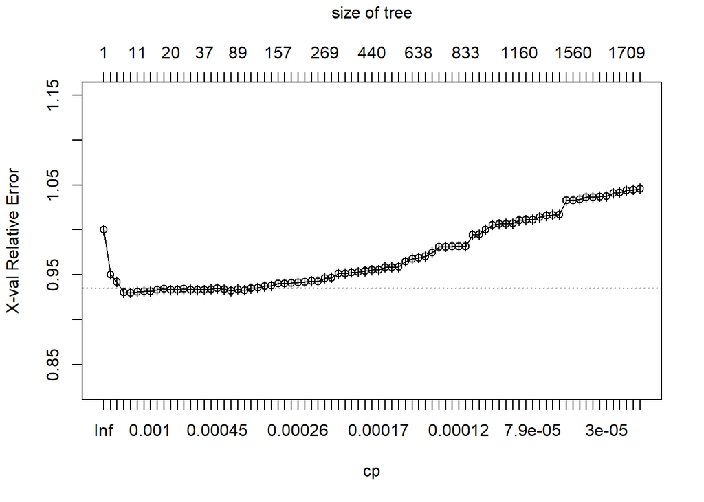

```r
plotcp(DB.tree.model)
```

```r
printcp(DB.tree.model)
```

```
##
## Classification tree:
## rpart(formula = DB.train$readmitted ~ ., data = DB.train, control = rpart.control(cp = 0,
##     minsplit = 30, xval = 10, maxsurrogate = 0))
##
## Variables actually used in tree construction:
##  [1] A1Cresult                admission_type_id        age
##  [4] change                   diabetesMed              diag_1
##  [7] discharge_disposition_id gender                   glimepiride
## [10] glipizide                glyburide                insulin
## [13] max_glu_serum            metformin                num_lab_procedures
## [16] num_medications          num_procedures           number_diagnoses
## [19] number_emergency         number_inpatient         number_outpatient
## [22] pioglitazone             race                     repaglinide
## [25] rosiglitazone            time_in_hospital
```

[output cut: 87 more lines]

Find the cp that produces the smallest xerror

```r
num<- which.min(DB.tree.model$cptable[,4])
min_cp<- DB.tree.model$cptable[num,1]
minimum_xerror <- DB.tree.model$cptable[num,4]
cbind(num=num,min_cp=min_cp,minimum_xerror = minimum_xerror)
```

```
##   num      min_cp minimum_xerror
## 5   5 0.001438627      0.9299183
```

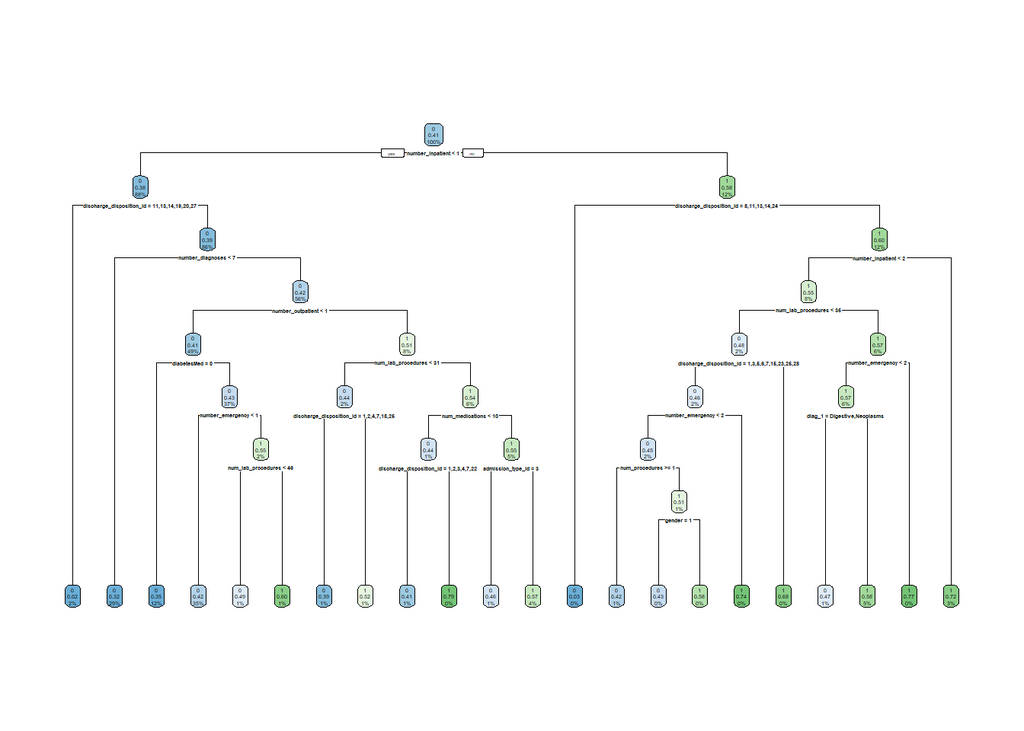

```r
DB.tree.pruned <- rpart(DB.train$readmitted~.,data=DB.train,control=rpart.control(
  cp=0.00061655,minsplit=30,xval=10, maxsurrogate=0))
rpart.plot(DB.tree.pruned)
```

```r
print(DB.tree.pruned)
```

```
## n= 48041
##
## node), split, n, loss, yval, (yprob)
##       * denotes terminal node
##
##   1) root 48041 19463 0 (0.59486688 0.40513312)
##     2) number_inpatient< 0.5 42153 16036 0 (0.61957631 0.38042369)
##       4) discharge_disposition_id=11,13,14,19,20,27 897    19 0 (0.97881828 0.02118172) *
##       5) discharge_disposition_id=1,2,3,4,5,6,7,8,9,10,12,15,16,17,18,22,23,24,25,28 41256 16017 0 (0.61176556 0.38823444)
##        10) number_diagnoses< 6.5 14120  4499 0 (0.68137394 0.31862606) *
##        11) number_diagnoses>=6.5 27136 11518 0 (0.57554540 0.42445460)
##          22) number_outpatient< 0.5 23444  9637 0 (0.58893534 0.41106466)
##            44) diabetesMed=0 5686  2016 0 (0.64544495 0.35455505) *
##            45) diabetesMed=1 17758  7621 0 (0.57084131 0.42915869)
##              90) number_emergency< 0.5 16654  7018 0 (0.57859974 0.42140026) *
##              91) number_emergency>=0.5 1104   501 1 (0.45380435 0.54619565)
##               182) num_lab_procedures< 45.5 533   260 0 (0.51219512 0.48780488) *
##               183) num_lab_procedures>=45.5 571   228 1 (0.39929947 0.60070053) *
##          23) number_outpatient>=0.5 3692  1811 1 (0.49052004 0.50947996)
##            46) num_lab_procedures< 30.5 1037   455 0 (0.56123433 0.43876567)
##              92) discharge_disposition_id=1,2,4,7,18,25 660   259 0 (0.60757576 0.39242424) *
##              93) discharge_disposition_id=3,5,6,15,17,22,23,28 377   181 1 (0.48010610 0.51989390) *
##            47) num_lab_procedures>=30.5 2655  1229 1 (0.46290019 0.53709981)
##              94) num_medications< 9.5 326   145 0 (0.55521472 0.44478528)
##               188) discharge_disposition_id=1,2,3,4,7,22 297   122 0 (0.58922559 0.41077441) *
##               189) discharge_disposition_id=6,15,18,23,24 29     6 1 (0.20689655 0.79310345) *
##              95) num_medications>=9.5 2329  1048 1 (0.44997853 0.55002147)
##               190) admission_type_id=3 342   157 0 (0.54093567 0.45906433) *
##               191) admission_type_id=1,4,5 1987   863 1 (0.43432310 0.56567690) *
##     3) number_inpatient>=0.5 5888  2461 1 (0.41796875 0.58203125)
##       6) discharge_disposition_id=8,11,13,14,24 178     6 0 (0.96629213 0.03370787) *
##       7) discharge_disposition_id=1,2,3,4,5,6,7,9,10,15,18,22,23,25,28 5710  2289 1 (0.40087566 0.59912434)
##        14) number_inpatient< 1.5 4053  1825 1 (0.45028374 0.54971626)
##          28) num_lab_procedures< 34.5 1001   477 0 (0.52347652 0.47652348)
##            56) discharge_disposition_id=1,3,5,6,7,15,23,25,28 938   434 0 (0.53731343 0.46268657)
##             112) number_emergency< 1.5 907   411 0 (0.54685777 0.45314223)
##               224) num_procedures>=0.5 552   230 0 (0.58333333 0.41666667) *
##               225) num_procedures< 0.5 355   174 1 (0.49014085 0.50985915)
##                 450) gender=1 159    68 0 (0.57232704 0.42767296) *
##                 451) gender=0 196    83 1 (0.42346939 0.57653061) *
##             113) number_emergency>=1.5 31     8 1 (0.25806452 0.74193548) *
##            57) discharge_disposition_id=2,4,18,22 63    20 1 (0.31746032 0.68253968) *
##          29) num_lab_procedures>=34.5 3052  1301 1 (0.42627785 0.57372215)
##            58) number_emergency< 1.5 2936  1274 1 (0.43392371 0.56607629)
##             116) diag_1=Digestive,Neoplasms 354   165 0 (0.53389831 0.46610169) *
##             117) diag_1=Circulatory,Genitourinary,Injury,Musculoskeletal,Other,Respiratory 2582  1085 1 (0.42021689 0.57978311) *
##            59) number_emergency>=1.5 116    27 1 (0.23275862 0.76724138) *
##        15) number_inpatient>=1.5 1657   464 1 (0.28002414 0.71997586) *
```

Interactions From the printed summary of the pruned tree model. We can see that the root node is splitted using number of inpatient admissions. With less previous inpatient admission, patients are less likely to have diabetes readmission. The first terminal nodes occur in the third layer after using previous discharge dispositions as split condition. As the nodes further splitted, the majority of terminal readmission nodes were classified based on MORE previous medical admissions and MORE different medical procedures.

Generate confusion matrix for training data for both full tree model and pruned tree model

Full Tree Model

```r
confusionMatrix(reference=DB.train$readmitted,data=predict(DB.tree.model,type="class"))
```

```
## Confusion Matrix and Statistics
##
##           Reference
## Prediction     0     1
##          0 23539  7556
##          1  5039 11907
##
##                Accuracy : 0.7378
##                  95% CI : (0.7339, 0.7418)
##     No Information Rate : 0.5949
##     P-Value [Acc > NIR] : < 2.2e-16
##
##                   Kappa : 0.4446
##
##  Mcnemar's Test P-Value : < 2.2e-16
##
##             Sensitivity : 0.8237
##             Specificity : 0.6118
##          Pos Pred Value : 0.7570
##          Neg Pred Value : 0.7026
##              Prevalence : 0.5949
##          Detection Rate : 0.4900
##    Detection Prevalence : 0.6473
##       Balanced Accuracy : 0.7177
##
##        'Positive' Class : 0
##
```

Pruned Tree Model

```r
(cm1<-confusionMatrix(reference=DB.train$readmitted,data=predict(DB.tree.pruned,type="class")))
```

```
## Confusion Matrix and Statistics
##
##           Reference
## Prediction     0     1
##          0 25613 14819
##          1  2965  4644
##
##                Accuracy : 0.6298
##                  95% CI : (0.6255, 0.6341)
##     No Information Rate : 0.5949
##     P-Value [Acc > NIR] : < 2.2e-16
##
##                   Kappa : 0.1494
##
##  Mcnemar's Test P-Value : < 2.2e-16
##
##             Sensitivity : 0.8962
##             Specificity : 0.2386
##          Pos Pred Value : 0.6335
##          Neg Pred Value : 0.6103
##              Prevalence : 0.5949
##          Detection Rate : 0.5331
##    Detection Prevalence : 0.8416
##       Balanced Accuracy : 0.5674
##
##        'Positive' Class : 0
##
```

It is easy to see that the Full Tree Model gives a better accuracy than Pruned Tree Model. But the pruned tree model is much easier to interpret.

### Holdout Validation Test

```r
pred.test<-predict(DB.tree.pruned,newdata=DB.test,type="class")
(cm2<-confusionMatrix(reference = DB.test$readmitted, data=pred.test))
```

```
## Confusion Matrix and Statistics
##
##           Reference
## Prediction     0     1
##          0 10989  6330
##          1  1313  1957
##
##                Accuracy : 0.6288
##                  95% CI : (0.6221, 0.6354)
##     No Information Rate : 0.5975
##     P-Value [Acc > NIR] : < 2.2e-16
##
##                   Kappa : 0.1436
##
##  Mcnemar's Test P-Value : < 2.2e-16
##
##             Sensitivity : 0.8933
##             Specificity : 0.2362
##          Pos Pred Value : 0.6345
##          Neg Pred Value : 0.5985
##              Prevalence : 0.5975
##          Detection Rate : 0.5337
##    Detection Prevalence : 0.8412
##       Balanced Accuracy : 0.5647
##
##        'Positive' Class : 0
##
```

```r
cbind(Train.Accuracy=as.numeric(cm1$overall[1]),
      Test.Accuracy=as.numeric(cm2$overall[1]),
      Train.TP=as.numeric(cm1$byClass[1]),
      Test.TP=as.numeric(cm2$byClass[1]),
      Train.FP=(1-as.numeric(cm1$byClass[2])),
      Test.FP=(1-as.numeric(cm2$byClass[2]))
      )
```

```
##      Train.Accuracy Test.Accuracy  Train.TP   Test.TP  Train.FP  Test.FP
## [1,]      0.6298162     0.6287824 0.8962489 0.8932694 0.7613934 0.763847
```

From above table, we can see that using pruned tree model, the predicted value Accuracy, True positive rate and False positive rate are very similar between train and test data. The pruned tree model result is very stable.

The accuracy of the pruned tree model is very close to the part 1 logistic Regression Model accuracy(0.6297). The logistical Regression model produced a slightly worse TP rate(0.8769), but it also produced a smaller FP rate (0.737). Overall both models yielded very similar results. Both are not good model due to the high FP rates. A better predictor selection should be considered for both models.